# Is a McMansion good for a McLoan ?

## by Daniel Cornea

## Investigation Overview

The overall goal of this presentation is to look at the interdepencies of homeownership and borrowing money on the Prosper.com platform

## Dataset Overview

The dataset that we look at is the Prosper.com operated by the Prosper Marketplace, Inc a peer to peer lending company

## Homeownership Distribution

As you can see from the slide the distribution is about equal for people who own a home and for those who do not

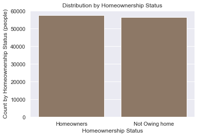

```python
# building the countplot
base_color = sb.color_palette()[5]
sns =  sb.countplot(data = loans, x = 'IsBorrowerHomeowner', color = base_color, order = loans.IsBorrowerHomeowner.value_counts().index)
sns.set(xlabel='Homeownership Status', ylabel= 'Count by Homeownership Status (people)')

plt.xticks(np.arange(2), ['Homeowners', 'Not Owing home'])
sns.set_title("Distribution by Homeownership Status");
```

## Relationship between loan size and interest charghed by homeownership

In the next slide, you will see how owning or not owning a home might influence the loan size you have and the interest charged on that loan

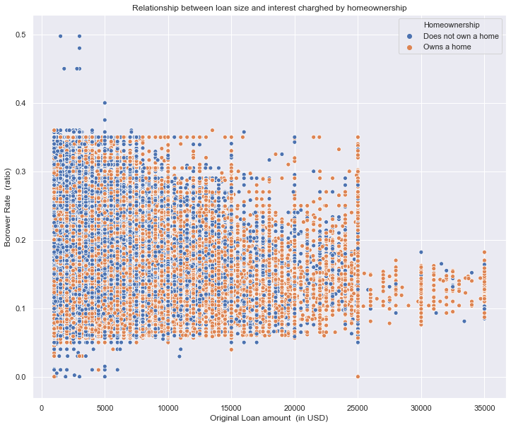

```python
# defining the size of the figure
plt.figure(figsize=(12,10))
# choosing the color palette
base_color = sb.color_palette()[2]
# building the scatterplot
sns = sb.scatterplot(data = loans, x = 'LoanOriginalAmount', y = 'BorrowerRate', hue = 'IsBorrowerHomeowner')


sns.set(xlabel='Original Loan amount  (in USD)', ylabel= 'Borower Rate  (ratio)')
L=plt.legend()
L.get_texts()[0].set_text('Homeownership')
L.get_texts()[1].set_text('Does not own a home')
L.get_texts()[2].set_text('Owns a home')


sns.set_title("Relationship between loan size and interest charghed by homeownership");
```

## Interaction between Debt to Income Ratio, Loan Amount and homeownership

The homeowners seem to be clustered in the lower right of the graph, meaning that they lower debt to income ratio and therefore might afford bigger loan amounts

#### To answer the question in the title it seems that owning a McMansion tends to land you a bigger McLoan hence more McNuggets....

This is only a visual of the data, in order to make our conlucison more reliable additional more rigourous statistical testing is needed.

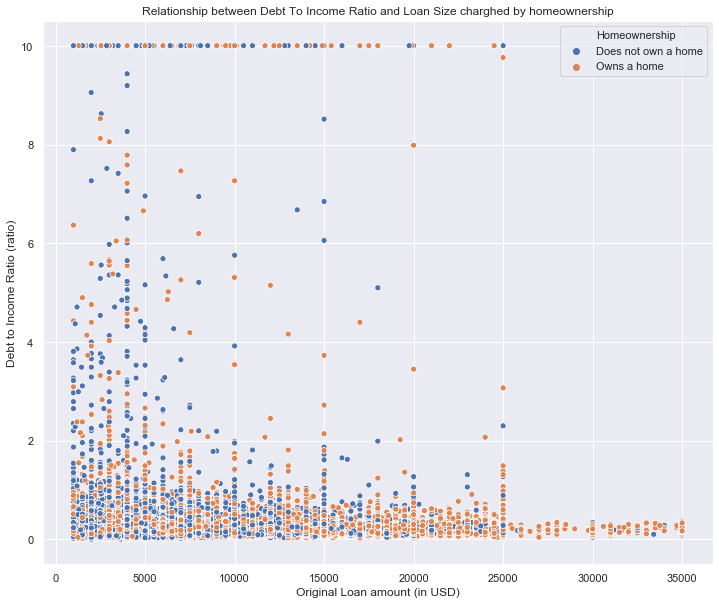

```python
plt.figure(figsize=(12,10))
base_color = sb.color_palette()[4]
sns = sb.scatterplot(data = loans, x = 'LoanOriginalAmount', y = 'DebtToIncomeRatio', hue = 'IsBorrowerHomeowner')
sns.set(xlabel='Original Loan amount (in USD)', ylabel= 'Debt to Income Ratio (ratio)')
L=plt.legend()
L.get_texts()[0].set_text('Homeownership')
L.get_texts()[1].set_text('Does not own a home')
L.get_texts()[2].set_text('Owns a home')

sns.set_title("Relationship between Debt To Income Ratio and Loan Size charghed by homeownership");
```